# Numerical Optimization

May 25, 2019

## Agenda

- Basics of optimization
- Gradient descent
- Newton's method
- Curve-fitting
- R: `optim`, `nls`

## Examples of Optimization Problems

- Minimize mean-squared error of regression surface
- Maximize likelihood of distribution
- Maximize output of tanks from given supplies and factories;
- Maximize return of portfolio for given volatility
- Minimize cost of airline flight schedule

## Optimization Problems

Given an **objective function** \(f: \mathcal{D} \mapsto R\), find

\[ \DeclareMathOperator*{\argmax}{argmax} \DeclareMathOperator*{\argmin}{argmin} \theta^* = \argmin_{\theta}{f(\theta)} \]

Basics: maximizing \(f\) is minimizing \(-f\):

\[ \argmax_{\theta}{f(\theta)}= \argmin_{\theta}{-f(\theta)} \]

If \(h\) is strictly increasing (e.g., \(\log\)), then

\[ \argmin_{\theta}{f(\theta)} = \argmin_{\theta}{h(f(\theta))} \]

## Considerations

- Approximation: How close can we get to \(\theta^*\), and/or \(f(\theta^*)\)?
- Time complexity: How many computer steps does that take?  
  Varies with precision of approximation, niceness of \(f\), size of \(\mathcal{D}\), size of data, method…
- Most optimization algorithms use **successive approximation**, so distinguish number of iterations from cost of each iteration

## You remember calculus, right?

Suppose \(x\) is one dimensional and \(f\) is smooth. If \(x^*\) is an **interior** minimum / maximum / extremum point

\[ {\left. \frac{df}{dx} \right|}_{x=x^*} = 0 \]

If \(x^*\) a minimum, \[ {\left. \frac{d^2f}{dx^2}\right|}_{x=x^*} > 0 \]

This all carries over to multiple dimensions:

At an **interior extremum**, \[ \nabla f(\theta^*) = 0 \]

At an **interior minimum**, \[ \nabla^2 f(\theta^*) \geq 0 \] meaning for any vector \(v\), \[ v^T \nabla^2 f(\theta^*) v \geq 0 \] \(\nabla^2 f =\) the **Hessian**, \(\mathbf{H}\)

\(\theta\) might just be a **local** minimum

## Gradients and Changes to f

\[ f^{\prime}(x_0) = {\left. \frac{df}{dx}\right|}_{x=x_0} = \lim_{x\rightarrow x_0}{\frac{f(x)-f(x_0)}{x-x_0}} \]

\[ f(x) \approx f(x_0) +(x-x_0)f^{\prime}(x_0) \]

Locally, the function looks linear; to minimize a linear function, move down the slope

Multivariate version: \[ f(\theta) \approx f(\theta_0) + (\theta-\theta_0) \cdot \nabla f(\theta_0) \]

\(\nabla f(\theta_0)\) points in the direction of fastest ascent at \(\theta_0\)

## Gradient Descent

1. Start with initial guess for \(\theta\), step-size \(\eta\)
2. While ((not too tired) and (making adequate progress))
- Find gradient \(\nabla f(\theta)\)
- Set \(\theta \leftarrow \theta - \eta \nabla f(\theta)\)
1. Return final \(\theta\) as approximate \(\theta^*\)

Variations: adaptively adjust \(\eta\) to make sure of improvement or search along the gradient direction for minimum

## Taylor Series

What if we do a quadratic approximation to \(f\)?

\[ f(x) \approx f(x_0) + (x-x_0)f^{\prime}(x_0) + \frac{1}{2}(x-x_0)^2 f^{\prime\prime}(x_0) \]

Special cases of general idea of Taylor approximation

Simplifies if \(x_0\) is a minimum since then \(f^{\prime}(x_0) = 0\):

\[ f(x) \approx f(x_0) + \frac{1}{2}(x-x_0)^2 f^{\prime\prime}(x_0) \]

Near a minimum, smooth functions look like parabolas

Carries over to the multivariate case: \[ f(\theta) \approx f(\theta_0) + (\theta-\theta_0) \cdot \nabla f(\theta_0) + \frac{1}{2}(\theta-\theta_0)^T \mathbf{H}(\theta_0) (\theta-\theta_0) \]

## Minimizing a Quadratic

If we know \[ f(x) = ax^2 + bx + c \]

we minimize exactly:

\[ \begin{eqnarray*} 2ax^* + b & = & 0\\ x^* & = & \frac{-b}{2a} \end{eqnarray*} \]

If \[ f(x) = \frac{1}{2}a (x-x_0)^2 + b(x-x_0) + c \]

then \[ x^* = x_0 - a^{-1}b \]

## Newton's Method

Taylor-expand for the value *at the minimum* \(\theta^*\) \[ f(\theta^*) \approx f(\theta) + (\theta^*-\theta) \nabla f(\theta) + \frac{1}{2}(\theta^*-\theta)^T \mathbf{H}(\theta) (\theta^*-\theta) \]

Take gradient, set to zero, solve for \(\theta^*\): \[ \begin{eqnarray*} 0 & = & \nabla f(\theta) + \mathbf{H}(\theta) (\theta^*-\theta) \\ \theta^* & = & \theta - {\left(\mathbf{H}(\theta)\right)}^{-1} \nabla f(\theta) \end{eqnarray*} \]

Works *exactly* if \(f\) is quadratic  
and \(\mathbf{H}^{-1}\) exists, etc.

If \(f\) isn't quadratic, keep pretending it is until we get close to \(\theta^*\), when it will be nearly true

## Newton's Method: The Algorithm

1. Start with guess for \(\theta\)
2. While ((not too tired) and (making adequate progress))
- Find gradient \(\nabla f(\theta)\) and Hessian \(\mathbf{H}(\theta)\)
- Set \(\theta \leftarrow \theta - \mathbf{H}(\theta)^{-1} \nabla f(\theta)\)
1. Return final \(\theta\) as approximation to \(\theta^*\)

Like gradient descent, but with inverse Hessian giving the step-size

"This is about how far you can go with that gradient"

## Curve-Fitting by Optimizing

We have data \((x_1, y_1), (x_2, y_2), \ldots (x_n, y_n)\)

We also have possible curves, \(r(x;\theta)\)

e.g., \(r(x) = x \cdot \theta\)

e.g., \(r(x) = \theta_1 x^{\theta_2}\)

## Curve-Fitting by Optimizing

Least-squares curve fitting:

\[ \hat{\theta} = \argmin_{\theta}{\frac{1}{n}\sum_{i=1}^n{(y_i - r(x_i;\theta))^2}} \]

"Robust" curve fitting: \[ \hat{\theta} = \argmin_{\theta}{\frac{1}{n}\sum_{i=1}^{n}{\psi(y_i - r(x_i;\theta))}} \]

## Derivatives in R

```r
f <- expression(5*x^2+3*x+1) ; deriv(f,"x")
```

```
## expression({
##     .value <- 5 * x^2 + 3 * x + 1
##     .grad <- array(0, c(length(.value), 1L), list(NULL, c("x")))
##     .grad[, "x"] <- 5 * (2 * x) + 3
##     attr(.value, "gradient") <- .grad
##     .value
## })
```

```r
x <- 2:4 ; eval(deriv(f,"x"))
```

```
## [1] 27 55 93
## attr(,"gradient")
##       x
## [1,] 23
## [2,] 33
## [3,] 43
```

## Integrate in R

```r
g <- function(x) eval(f)
integrate(g,lower = 0,upper = 2)
```

```
## 21.33333 with absolute error < 2.4e-13
```

```r
h <- function(x) exp(cos(x)^2)+exp(sin(x))
integrate(h,1,5)
```

```
## 11.99573 with absolute error < 0.00046
```

## Optimization in R: optim()

```
optim(par, fn, gr, method, control, hessian)
```

- `fn`: function to be minimized; mandatory
- `par`: initial parameter guess; mandatory
- `gr`: gradient function; only needed for some methods
- `method`: defaults to a gradient-free method (``Nedler-Mead''), could be BFGS (Newton-ish)
- `control`: optional list of control settings
- (maximum iterations, scaling, tolerance for convergence, etc.)
- `hessian`: should the final Hessian be returned? default FALSE

Return contains the location (`$par`) and the value (`$val`) of the optimum, diagnostics, possibly `$hessian`

## Optimization in R: optim()

```r
gmp <- read.table("../data/gmp.dat")
gmp$pop <- gmp$gmp/gmp$pcgmp
library(numDeriv)
mse <- function(theta) { mean((gmp$pcgmp - theta[1]*gmp$pop^theta[2])^2) }
grad.mse <- function(theta) { grad(func=mse,x=theta) }
theta0=c(5000,0.15)
fit1 <- optim(theta0,mse,grad.mse,method="BFGS",hessian=TRUE)
```

## fit1: Newton-ish BFGS method

```r
fit1[1:3]
```

```
## $par
## [1] 6493.2563738    0.1276921
##
## $value
## [1] 61853983
##
## $counts
## function gradient
##       63       11
```

## fit1: Newton-ish BFGS method

```r
fit1[4:6]
```

```
## $convergence
## [1] 0
##
## $message
## NULL
##
## $hessian
##             [,1]         [,2]
## [1,] 5.25021e+01      4422070
## [2,] 4.42207e+06 375729087977
```

## nls

`optim` is a general-purpose optimizer

So is `nlm` — try them both if one doesn't work

`nls` is for nonlinear least squares

## nls

```
nls(formula, data, start, control, [[many other options]])
```

- `formula`: Mathematical expression with response variable, predictor variable(s), and unknown parameter(s)
- `data`: Data frame with variable names matching `formula`
- `start`: Guess at parameters (optional)
- `control`: Like with `optim` (optional)

Returns an `nls` object, with fitted values, prediction methods, etc.

The default optimization is a version of Newton's method

## fit2: Fitting the Same Model with nls()

```r
fit2 <- nls(pcgmp~y0*pop^a,data=gmp,start=list(y0=5000,a=0.1))
summary(fit2)
```

```
##
## Formula: pcgmp ~ y0 * pop^a
##
## Parameters:
##     Estimate Std. Error t value Pr(>|t|)
## y0 6.494e+03  8.565e+02   7.582 2.87e-13 ***
## a  1.277e-01  1.012e-02  12.612  < 2e-16 ***
## ---
## Signif. codes:  0 '***' 0.001 '**' 0.01 '*' 0.05 '.' 0.1 ' ' 1
##
## Residual standard error: 7886 on 364 degrees of freedom
##
## Number of iterations to convergence: 5
## Achieved convergence tolerance: 1.751e-07
```

## fit2: Fitting the Same Model with nls()

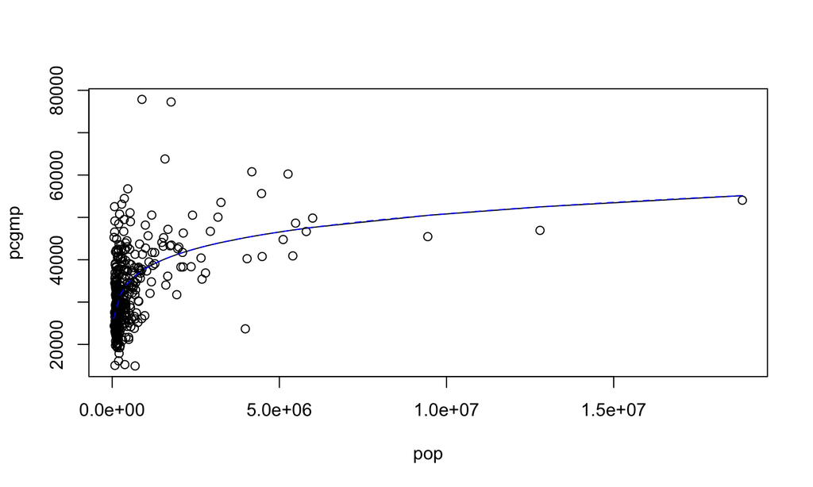

```r
plot(pcgmp~pop,data=gmp)
pop.order <- order(gmp$pop)
lines(gmp$pop[pop.order],fitted(fit2)[pop.order])
curve(fit1$par[1]*x^fit1$par[2],add=TRUE,lty="dashed",col="blue")
```

## Maximize log-likelihood

Imagine that we have a sample that was drawn from a normal distribution with unknown mean, \(\mu\), and variance, \(\sigma^2\). The objective is to estimate these parameters. The normal log-likelihood function is given by

\[ l = −.5 n ln (2\pi)−.5 n ln(\sigma^2)− \frac{1}{2\sigma^2} \sum_{i} (y_i -\mu)^2 \] We can program this function in the following way:

```r
normal.lik<-function(theta,y) {
  mu<-theta[1]
  sigma2<-theta[2]
  n <- length(y)
  logl <- -.5*n*log(2*pi) -.5*n*log(sigma2) - (1/(2*sigma2))*sum((y-mu)**2)
  return (-logl)
}
```

Once the log-likelihood function has been declared, then the optim command can be invoked. The minimal specification of this command is

`optim(starting values, log-likelihood, data)`

Given a vector of data, y, the parameters of the normal distrib- ution can be estimated using

```r
y <- rnorm(1000,1,5);
optim(c(0,1),normal.lik,y=y,method="BFGS")
```

```
## $par
## [1]  1.017934 24.771340
##
## $value
## [1] 3023.782
##
## $counts
## function gradient
##       36       20
##
## $convergence
## [1] 0
##
## $message
## NULL
```

## Summary

1. Trade-offs: complexity of iteration vs. number of iterations vs. precision of approximation
- Gradient descent: less complex iterations, more guarantees, less adaptive
- Newton: more complex iterations, but few of them for good functions, more adaptive, less robust
1. Start with pre-built code like `optim` or `nls`, implement your own as needed